# Hausübung 2 Lösung

# Hausübung 2

## 📅 Formalitäten und Abgabe

- **Abgabe bis:** Freitag 28.11, 23:55 via ILIAS
- **Zip-Datei benennen:** `vorname_nachname.zip`
  - **Gerendertes Skript:** `vorname_nachname_hausuebung_2.html`
  - **Ungerendertes Quarto-Skript:** `vorname_nachname_hausuebung_2.qmd`
- **Peer Feedback:** Bis 3.12 direkt an die Person und im Forum als Zusammenfassung. Im Forum bitte auch Namen der Person, für die das Feedback bestimmt ist, nennen.

## Aufgabe 1: Datensatz einlesen und Deskriptive Statistik

📥 Download practice_dataset2.csv

### 1.1 Vorbereitungen und Datensatz einlesen

Stelle in deinem Quarto Header die folgenden Dinge ein. Achtung: Achte auf die Einrückung der Einstellungen. Wenn das nicht von Hand klappt kann man sich bei der Einrückung von einem LLM helfen lassen. 😉.

- **format: html**
- **embed-resources: true**
- **table of contents (toc) = true**

Lies den folgenden Datensatz ein: **Practice_dataset2**

**Lösungen**

```r
practice_dataset2 <- read_delim("raw/practice_dataset2.csv", delim = ";", escape_double = FALSE, trim_ws = TRUE)
```

### 1.2 Mittelwert und Standardabweichung (Self-Efficacy)

Berechne den **Mittelwert** und die **Standardabweichung** der Variable `self_efficacy` für jede Gruppe (`condition`). Runde die Ergebnisse jeweils auf drei Nachkommastellen. Speichere diese deskriptive Statistik in einen neuen Dataframe ab.

**Lösungen**

```r
practice_dataset_sum <- practice_dataset2 |>
  group_by(condition) |>
  summarize(
    mean_selfeff = round(mean(self_efficacy, na.rm = TRUE), 3),
    sd_selfeff = round(sd(self_efficacy, na.rm = TRUE), 3) #mit einem "," getrennt, koennt ihr beliebig viele zusammenfassende Berechnungen hintereinander in einem Call durchfuehren
  )
```

### 1.3 Tabelle formatieren mit `kable`

Nutze `kable` um Formatierungen am unter 1.2 erstellten Dataframe durchzuführen (Überschrift ergänzen, Spalten benennen, Nachkommastellen anpassen).

**Lösungen**

```r
kable(practice_dataset_sum,   caption = "Zusammenfassung der Self-Efficacy nach Bedingung",   col.names = c("Bedingung", "Mittelwert Self-Efficacy", "SD Self-Efficacy"),   digits = 3 )
```

Zusammenfassung der Self-Efficacy nach Bedingung

| Bedingung | Mittelwert Self-Efficacy | SD Self-Efficacy |
| --- | --- | --- |
| control | 68.993 | 10.21 |
| experimental | 70.596 | 8.25 |

### 1.4 Schiefe und Kurtosis

Berechne zusätzlich die **Schiefe** (`skew`) und **Kurtosis** (`kurtosi`) der Variable `self_efficacy` pro Gruppe (`condition`), mit Funktionen aus dem Paket `psych`.

**Lösungen**

```r
practice_dataset_dis <- practice_dataset2 |>
  group_by(condition) |>
  summarize(
    skew = round(psych::skew(self_efficacy), 3),
    kurtosis = round(psych::kurtosi(self_efficacy), 3))  #Die Ergebnisse werden auf 3 Nachkommastellen gerundet

print(practice_dataset_dis)
```

```
# A tibble: 2 × 3
  condition     skew kurtosis
  <chr>        <dbl>    <dbl>
1 control      0.11    -0.217
2 experimental 0.025    0.22
```

## Aufgabe 2: Wide-to-Long Transformation

### 2.1 Wide-to-Long Transformation

Der Originaldatensatz enthält die Spalten `pre_mood`, `mid_mood`, `post_mood`. Verwandle diese mithilfe von `pivot_longer()` in einen **Long-Datensatz** namens `mood_long`. Die neue Spalte mit den Zeitpunkten soll `mood_time` heißen, die mit den Werten `mood_rating`.

**Lösungen**

```r
mood_long <- practice_dataset2 |>
  pivot_longer(
    cols = starts_with("pre_mood"):post_mood, #hier waehlt ihr die Spalten aus, welche vom breiten (wide) Datensatz in einen laengeren (long) Datensatz ueberfuehrt werden sollen
    names_to = "mood_time", #hier benennt ihr die Spalte, in welcher die alten Spaltennamen abgelegt werden
    values_to = "mood_rating" #hier benennt ihr die Spalte, in welcher die alten Spaltenwerte abgelegt werden
  )

#alternativen
mood_long <- practice_dataset2 |>
  pivot_longer(
    cols = c("pre_mood", "mid_mood", "post_mood"), #hier mit der expliziten Nennung aller entsprechenden Spalten
    names_to = "mood_time",
    values_to = "mood_rating"
  )

mood_long <- practice_dataset2 |>
  pivot_longer(
    cols = ends_with("mood"), #hier anhand dessen, womit der Spaltenname endet
    names_to = "mood_time",
    values_to = "mood_rating"
  )
```

## Aufgabe 3: Plot - Verlaufsdiagramm

### 3.1 Vorbereitung

Im nächsten Schritt verwenden wir den LONG-Datensatz (Siehe Aufgabe 2.1), um den Verlauf über die verschiedenen Zeitpunkte darzustellen. Das Ziel ist es, die Stimmung (mood) zu den unterschiedlichen Zeitpunkten, aggregiert nach den Konditionen, als Verlaufsdiagramm abzubilden.

- Dafür soll mood_time in einen Faktor mit geordneten Faktorstufen (pre, mid und post) umgewandelt werden.
- Erstelle einen Summary, welches die für den Plot benötigten Angaben zusammenfasst (Durschschnittlicher Mood gruppiert nach Condition und Zeitpunkt).

**Lösungen**

```r
mood_long$mood_time <- factor(
  mood_long$mood_time,
  levels = c("pre_mood", "mid_mood", "post_mood")
)

levels(mood_long$mood_time)
```

```
[1] "pre_mood"  "mid_mood"  "post_mood"
```

```r
data_plot <- mood_long |>
  group_by(mood_time, condition) |>
  summarise(mean_mood = mean(mood_rating))
```

### 3.2 Initialer Lineplot

Plotte die Elemente `mood_time` und `mean_mood`. Gruppiere die conditions nach Farbe.

💡Tipp: Wenn du den Plot einem Objekt zuweist, kannst du ihn weiterverwenden, indem du das Objekt aufrufst und erweiterst. So musst du den Code nicht jedes Mal neu ausschreiben.

**Lösungen**

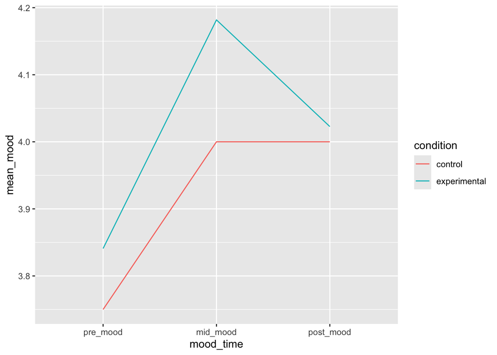

### 3.3 Farbpalette für Farbenblinde

Passe nun den Plot aus 3.2 so an, dass er eine **Farbpalette** verwendet, die für farbenblinde Personen geeignet ist: Nutze die folgende Palette.

Tipp: Verwende: `scale_color_manual`

**Lösungen**

```r
cb_palette <- c(   "#000000", "#E69F00", "#56B4E9", "#009E73",   "#F0E442", "#0072B2", "#D55E00", "#CC79A7" )
```

**Lösungen**

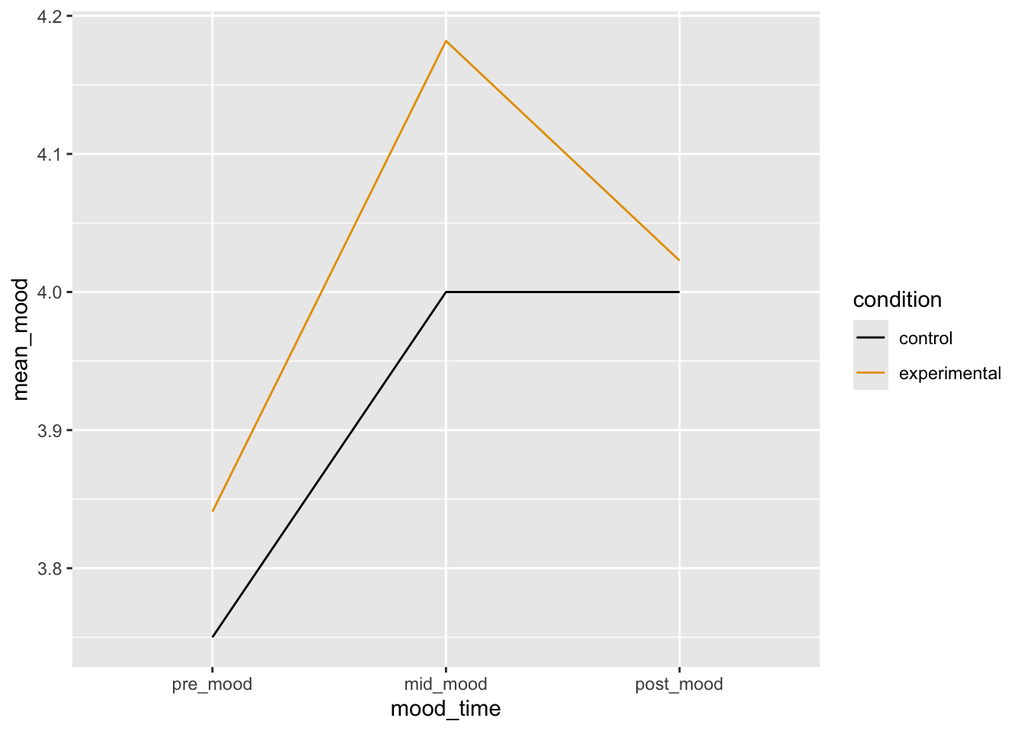

```r
plot_farbe <- plot +
  scale_color_manual(values = cb_palette)

plot_farbe
```

### 3.4 Datenpunkte hinzufügen

Füge mit `geom_point()` die einzelnen Punkte auf der Linie ein. Stelle die grösse (`size()` auf 3)

**Lösungen**

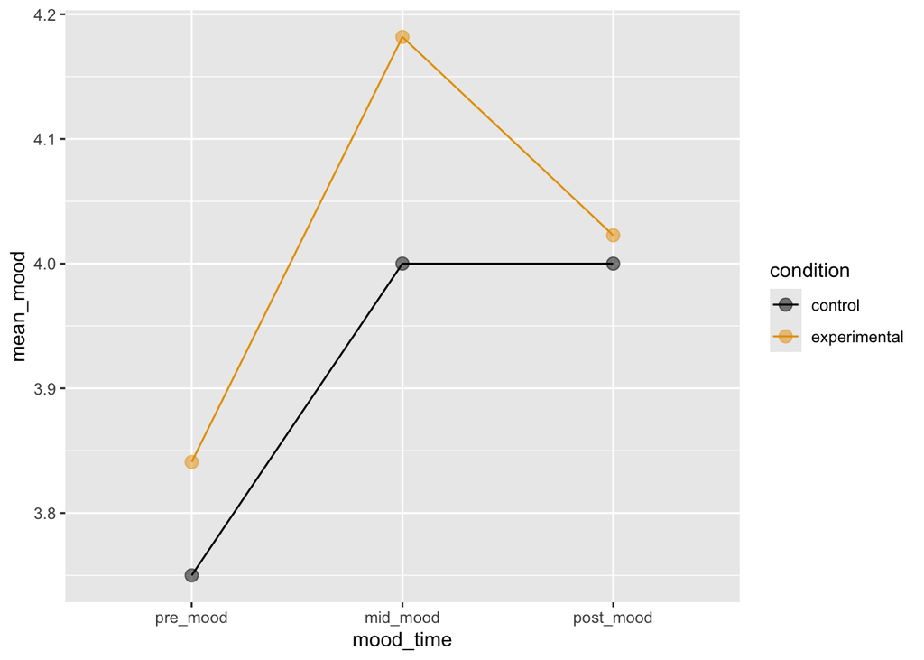

```r
plot_2 <- plot_farbe +
 geom_point(alpha = 0.5, size = 3)

plot_2
```

### 3.5 Finale Formatierung

Füge dem Diagramm **Titel** sowie **Achsenbeschriftungen** zu deinem Plot und verwende ein Theme das du passend findest.

**Lösungen**

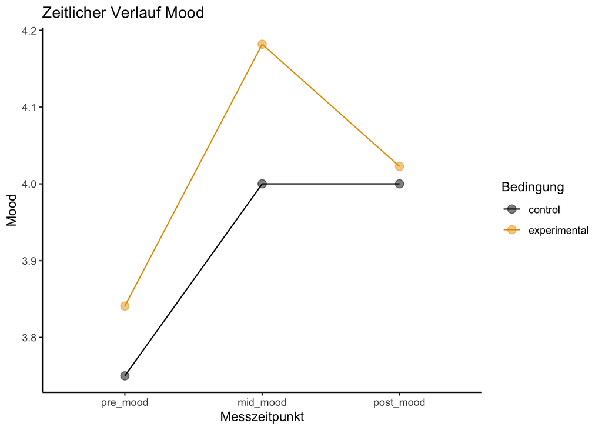

```r
plot_3 <- plot_2 +
  labs(
    title = "Zeitlicher Verlauf Mood",
    y = "Mood",
    x = "Messzeitpunkt",
    color = "Bedingung"   ) +
  theme_classic()
print(plot_3)
```

### 3.6 Plot speichern

Speichere den Plot ab mit `ggsave` als **png** ab.

**Lösungen**

```r
ggsave("mein_plot.png", plot = plot_3)
```

## 4. Subsetting und *t*-Test

Erstelle aus dem ursprünglichen Wide Originaldatensatz einen neuen Datensatz `subset_mood`, der nur Daten der Gruppe **experimental** beinhaltet.

**Lösungen**

```r
subset_mood <- practice_dataset2 |>   filter(condition == "experimental")
```

### 4.1 Gepaarter *t*-Test

Prüfe nun (anhand des unter 4. erstellen Datensatzes) mittels eines gepaarten *t*-Test ob sich `pre_mood` und `post_mood` in der Gruppe *experimental* unterscheiden. Nutze dafür die Funktion `t.test()`. Lass dir das Ergebnis mit `print()` ausgeben.

**Lösungen**

```r
t_test_result <- t.test(subset_mood$pre_mood, subset_mood$post_mood, paired = TRUE)

print(t_test_result)
```

```
    Paired t-test

data:  subset_mood$pre_mood and subset_mood$post_mood
t = -0.42731, df = 43, p-value = 0.6713
alternative hypothesis: true mean difference is not equal to 0
95 percent confidence interval:
 -1.0399187  0.6762823
sample estimates:
mean difference
     -0.1818182
```

```r
# hier gilt paired = TRUE, da sich die beiden Messungen bedingen (sie sind beide von der selben Person, lediglich zu unterschiedlichen Zeitpunkten aufgenommen worden) = within-subjects Vergleich
```

## 5. Rendern und Hochladen

- Rendere dein Skript als HTML
- Lade deine Abgabe (Skript + HTML) als ZIP ordner in ILIAS hoch und schicke sie deinem/deiner Peepartner:in.